# RNA-Seq: quantification and DE analysis

Laura Toribio-Celestino

May 2023

### Loading required packages

```r
library(Rsubread)
library(DESeq2)
library(apeglm)
library(dplyr)
library(ggplot2)
library(pheatmap)
library(RColorBrewer)
library(EnhancedVolcano)
```

# Quantification with featureCounts

Let’s start by reading the sorted BAM files and the annotation SAF file located in this directory.

```r
bamfiles <- dir(".", ".bam$")
saffile <- dir(".", "saf$")
```

Next, gene-level quantification is performed using featureCounts, which is faster than other methods and requires less computer memory. Strandness was checked before running.

```r
fc <- featureCounts(bamfiles, annot.ext=saffile, strandSpecific=2, isPairedEnd=TRUE, nthreads=15)
```

[output not shown]

[output cut: 30 more lines]

```
## ||    Total alignments : 12251228                                             ||
## ||    Successfully assigned alignments : 11466350 (93.6%)                     ||
## ||    Running time : 0.23 minutes                                             ||
## ||                                                                            ||
## || Process BAM file C325c1.3.bam...                                           ||
## ||    Strand specific : reversely stranded                                    ||
## ||    Paired-end reads are included.                                          ||
## ||    Total alignments : 11223535                                             ||
## ||    Successfully assigned alignments : 10668688 (95.1%)                     ||
## ||    Running time : 0.18 minutes                                             ||
## ||                                                                            ||
## || Write the final count table.                                               ||
## || Write the read assignment summary.                                         ||
## ||                                                                            ||
## \\============================================================================//
```

Count data is exported to a TSV file. Here we’ll see some stats of the count data.

```r
write.table(x=data.frame(fc$annotation[,c("GeneID","Chr", "Length")], fc$counts, stringsAsFactors=FALSE), file="featureCounts.tsv", quote=FALSE, sep="\t", row.names=FALSE)
head(fc$counts)
```

```
##                    C325.1.bam C325.2.bam C325.3.bam C325c1.1.bam C325c1.2.bam
## cds-pgaptmp_000002         16         12         11           25           15
## cds-pgaptmp_000003         60         67         76           32           29
## cds-pgaptmp_000004         52         41         54           69           49
## cds-pgaptmp_000005        262        277        385          436          376
## cds-pgaptmp_000006         17          6          5            9           20
## cds-pgaptmp_000007         12          9          7           24           18
##                    C325c1.3.bam
## cds-pgaptmp_000002            5
## cds-pgaptmp_000003           76
## cds-pgaptmp_000004           89
## cds-pgaptmp_000005          537
## cds-pgaptmp_000006           11
## cds-pgaptmp_000007           18
```

```r
summary(fc$counts)
```

```
##    C325.1.bam        C325.2.bam          C325.3.bam         C325c1.1.bam
##  Min.   :      0   Min.   :      0.0   Min.   :      0.0   Min.   :      0.0
##  1st Qu.:     35   1st Qu.:     36.0   1st Qu.:     42.0   1st Qu.:     29.0
##  Median :    235   Median :    248.5   Median :    274.5   Median :    189.0
##  Mean   :   2103   Mean   :   2388.1   Mean   :   2432.3   Mean   :   2635.7
##  3rd Qu.:   1075   3rd Qu.:   1123.8   3rd Qu.:   1210.0   3rd Qu.:    901.8
##  Max.   :2025449   Max.   :2852671.0   Max.   :2529627.0   Max.   :2451796.0
##   C325c1.2.bam     C325c1.3.bam
##  Min.   :     0   Min.   :     0.0
##  1st Qu.:    23   1st Qu.:    20.0
##  Median :   173   Median :   149.0
##  Mean   :  2087   Mean   :  1941.9
##  3rd Qu.:  1002   3rd Qu.:   790.8
##  Max.   :967401   Max.   :608518.0
```

```r
fc$stat
```

```
##                           Status C325.1.bam C325.2.bam C325.3.bam C325c1.1.bam
## 1                       Assigned   11552291   13120092   13362945     14480631
## 2            Unassigned_Unmapped      27013      23156      22025        19281
## 3           Unassigned_Read_Type          0          0          0            0
## 4           Unassigned_Singleton          0          0          0            0
## 5      Unassigned_MappingQuality          0          0          0            0
## 6             Unassigned_Chimera          0          0          0            0
## 7      Unassigned_FragmentLength          0          0          0            0
## 8           Unassigned_Duplicate          0          0          0            0
## 9        Unassigned_MultiMapping          0          0          0            0
## 10          Unassigned_Secondary          0          0          0            0
## 11           Unassigned_NonSplit          0          0          0            0
## 12         Unassigned_NoFeatures     198415     189421     298639       160110
## 13 Unassigned_Overlapping_Length          0          0          0            0
## 14          Unassigned_Ambiguity     470314     487418     511284       487876
##    C325c1.2.bam C325c1.3.bam
## 1      11466350     10668688
## 2         15564         9485
## 3             0            0
## 4             0            0
## 5             0            0
## 6             0            0
## 7             0            0
## 8             0            0
## 9             0            0
## 10            0            0
## 11            0            0
## 12       144872        79218
## 13            0            0
## 14       624442       466144
```

The count matrices are prepared for the construction of the DESeqDataSet object. Gene IDs are set as row names.

```r
countdata <- fc$counts
colnames(countdata) <- gsub("\\.bam$", "", colnames(countdata))
nrow(countdata)
```

```
## [1] 5494
```

Plotting the total read counts of each sample.

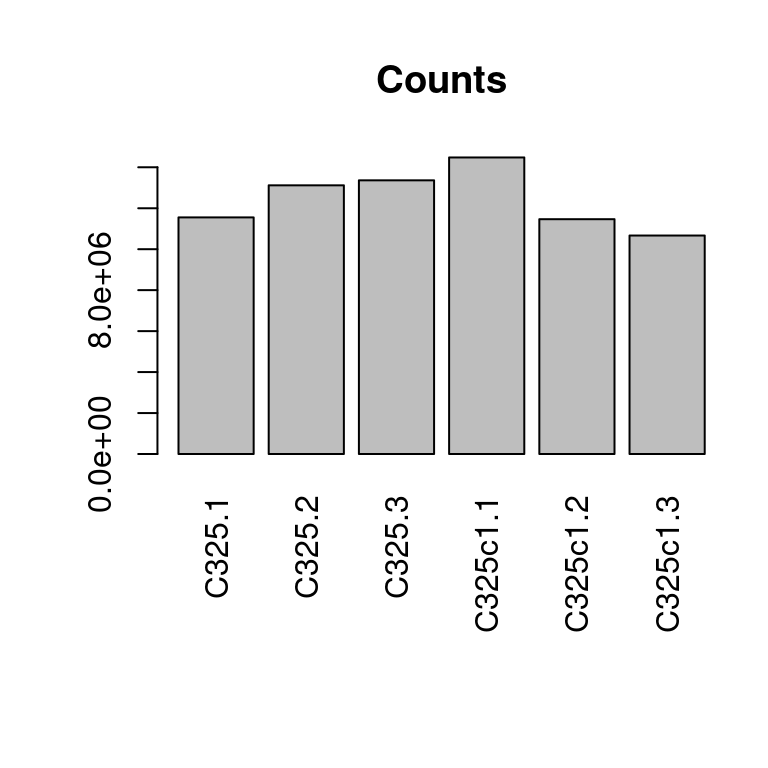

```r
par(mar=c(8,4,4,1)+0.1)
barplot(colSums(countdata), las=3, main="Counts")
```

# DESeqDataSet object and experimental design

Building the variables for the columns of the colData object. The condition of all samples and replicates is specified.

```r
condition <- c('wt', 'wt', 'wt', 'cur', 'cur', 'cur')
replicate <- c('1', '2', '3', '1', '2', '3')
coldata <- as.data.frame(cbind(colnames(countdata), condition, replicate))
coldata
```

```
##         V1 condition replicate
## 1   C325.1        wt         1
## 2   C325.2        wt         2
## 3   C325.3        wt         3
## 4 C325c1.1       cur         1
## 5 C325c1.2       cur         2
## 6 C325c1.3       cur         3
```

Constructing the DESeqDataSet object.

```r
dds <- DESeqDataSetFromMatrix(countData = countdata, colData = coldata, design = ~ condition)
head(dds)
```

```
## class: DESeqDataSet
## dim: 6 6
## metadata(1): version
## assays(1): counts
## rownames(6): cds-pgaptmp_000002 cds-pgaptmp_000003 ...
##   cds-pgaptmp_000006 cds-pgaptmp_000007
## rowData names(0):
## colnames(6): C325.1 C325.2 ... C325c1.2 C325c1.3
## colData names(3): V1 condition replicate
```

```r
nrow(dds)
```

```
## [1] 5494
```

The reference level of the condition’s factors must be specified. The reference will be defined as the pOXA-48-free version of the strain.

```r
dds$condition <- relevel(dds$condition, ref = "cur")
```

## Pre-filtering the dataset

```r
keep <- rowSums(counts(dds)) > 1
dds <- dds[keep,]
nrow(dds)
```

```
## [1] 5443
```

# Analysis of count data

Before exploratory analyses, count data is transformed to stabilize the variance across the mean. The rlog transformation is applied since it works best on small datasets (n<30), in comparison with the VST method.

```r
rld <- rlog(dds, blind = FALSE)
head(assay(rld))
```

```
##                      C325.1   C325.2   C325.3 C325c1.1 C325c1.2 C325c1.3
## cds-pgaptmp_000002 3.808786 3.581355 3.464736 4.266264 3.832595 3.322065
## cds-pgaptmp_000003 5.788983 5.846092 5.871191 5.371257 5.258421 6.314345
## cds-pgaptmp_000004 5.702465 5.458763 5.606328 6.088580 5.737876 6.509326
## cds-pgaptmp_000005 8.139846 8.147000 8.365833 8.773653 8.583479 9.172773
## cds-pgaptmp_000006 3.697916 3.039528 2.912199 3.361729 3.896959 3.608045
## cds-pgaptmp_000007 3.668245 3.465089 3.278687 4.288727 4.024624 4.194338
```

### Heatmap of distances between samples

To observe the similarities and dissimilarities between samples, we plot a heatmap of Euclidean distances. Replicates from each condition should cluster together.

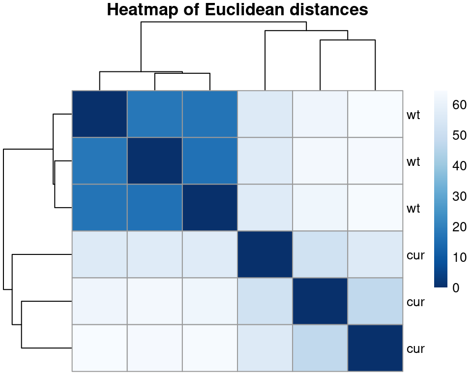

```r
sampleDists <- dist(t(assay(rld)))
sampleDistMatrix <- as.matrix(sampleDists)
rownames(sampleDistMatrix) <- paste(rld$condition, sep="-")
colnames(sampleDistMatrix) <- NULL
colors <- colorRampPalette(rev(brewer.pal(9, "Blues")))(255)
pheatmap(sampleDistMatrix,
         clustering_distance_rows=sampleDists,
         clustering_distance_cols=sampleDists,
         col=colors,
         main="Heatmap of Euclidean distances")
```

### PCA plot

In PCA plots, samples are projected onto the 2D plane such that they spread out in the two directions that explain most of the differences betweem them. The x-axis (PC1) is the direction that separates the data points the most. The y-axis (PC2) is the direction that separates the data the second most. The percent of the total variance that is contained in the direction is printed in the axis label. Replicates from each condition should cluster together.

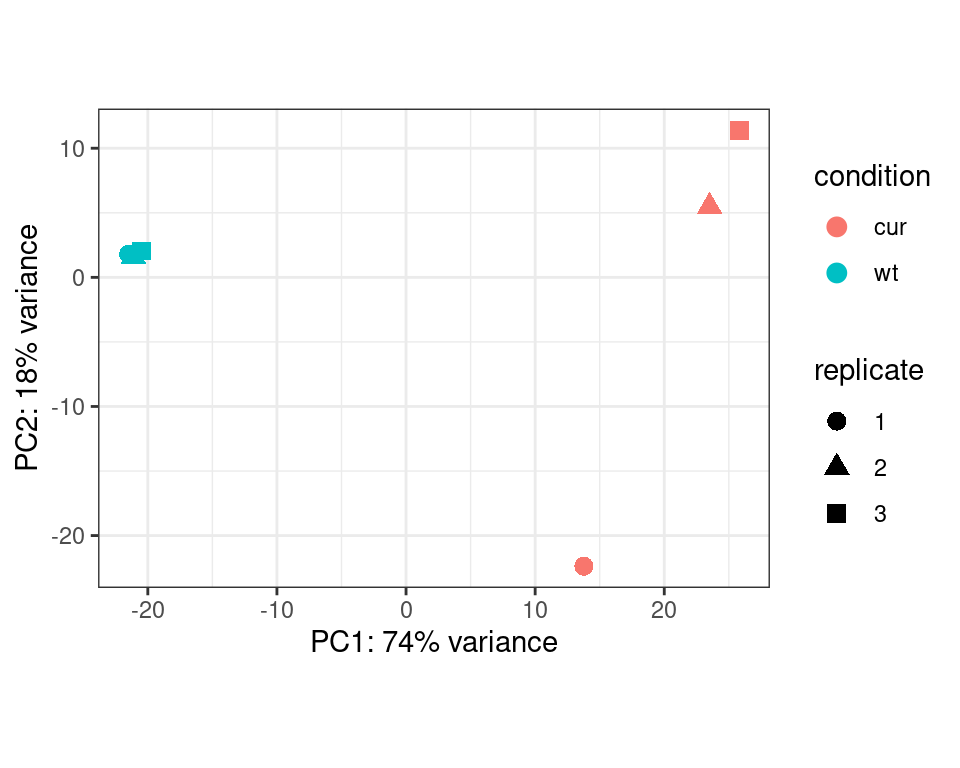

```r
pcaData <- plotPCA(rld, intgroup = c("condition", "replicate"), returnData = TRUE)
percentVar <- round(100 * attr(pcaData, "percentVar"))
ggplot(pcaData, aes(x = PC1, y = PC2, color = condition, shape = replicate)) +
  geom_point(size =3) +
  xlab(paste0("PC1: ", percentVar[1], "% variance")) +
  ylab(paste0("PC2: ", percentVar[2], "% variance")) +
  coord_fixed() +
  theme_bw()
```

## Differential expression analysis

As we have already specified an experimental design when we created the DESeqDataSet, we can run the differential expression pipeline on the raw counts:

```r
dds <- DESeq(dds)
resultsNames(dds)
```

```
## [1] "Intercept"           "condition_wt_vs_cur"
```

We’ll have a look at the summary of the unfiltered DE results. The LFC is shrunken with the apeglm method for visualizing results and ranking the genes for GSEA analysis.

```r
res <- results(dds)
res <- lfcShrink(dds, coef="condition_wt_vs_cur", type="apeglm")
```

```
## using 'apeglm' for LFC shrinkage. If used in published research, please cite:
##     Zhu, A., Ibrahim, J.G., Love, M.I. (2018) Heavy-tailed prior distributions for
##     sequence count data: removing the noise and preserving large differences.
##     Bioinformatics. https://doi.org/10.1093/bioinformatics/bty895
```

```r
res
```

```
## log2 fold change (MAP): condition wt vs cur
## Wald test p-value: condition wt vs cur
## DataFrame with 5443 rows and 5 columns
##                     baseMean log2FoldChange     lfcSE     pvalue      padj
##                    <numeric>      <numeric> <numeric>  <numeric> <numeric>
## cds-pgaptmp_000002   13.9723     -0.2891500  0.502700 0.42462914 0.6430688
## cds-pgaptmp_000003   56.9078      0.0863213  0.423258 0.80073556 0.9055173
## cds-pgaptmp_000004   61.7460     -0.7079271  0.422248 0.04193909 0.1451424
## cds-pgaptmp_000005  394.3224     -0.8218970  0.352632 0.00789269 0.0439554
## cds-pgaptmp_000006   11.6973     -0.4486830  0.569473 0.24085268 0.4607335
## ...                      ...            ...       ...        ...       ...
## cds-pgaptmp_005512   1.63776      0.0933274  0.677498  0.6504160        NA
## cds-pgaptmp_005513   1.10539      0.2587132  0.720207  0.2631695        NA
## cds-pgaptmp_005514  40.12851     -1.1256947  0.912378  0.0282456  0.110653
## cds-pgaptmp_005515   1.80794     -0.5574480  0.949008  0.0608693        NA
## cds-pgaptmp_005516   9.22998     -0.5817630  0.674583  0.1503539  0.342851
```

```r
summary(res)
```

```
##
## out of 5443 with nonzero total read count
## adjusted p-value < 0.1
## LFC > 0 (up)       : 529, 9.7%
## LFC < 0 (down)     : 676, 12%
## outliers [1]       : 33, 0.61%
## low counts [2]     : 423, 7.8%
## (mean count < 5)
## [1] see 'cooksCutoff' argument of ?results
## [2] see 'independentFiltering' argument of ?results
```

The unfiltered DE results are exported to a TSV file (contains NAs and non-significant DEGs).

```r
## The saf file, which contains the RefSeq IDs is read
saftable <- read.csv(saffile, header=TRUE, sep="\t")
saftable <- as.data.frame(saftable)
## Merge with normalized count data and annotation
resdata <- merge(as.data.frame(res), as.data.frame(counts(dds, normalized=TRUE)), by="row.names", sort=FALSE)
names(resdata)[1] <- "GeneID"
resdata <- merge(x=as.data.frame(resdata), saftable, by="GeneID")
head(resdata)
```

```
##               GeneID  baseMean log2FoldChange     lfcSE     pvalue      padj
## 1 cds-pgaptmp_000001   1.66585    -0.19011738 0.6592093 0.50685578        NA
## 2 cds-pgaptmp_000002  13.97230    -0.28915002 0.5026996 0.42462914 0.6430688
## 3 cds-pgaptmp_000003  56.90785     0.08632132 0.4232579 0.80073556 0.9055173
## 4 cds-pgaptmp_000004  61.74601    -0.70792708 0.4222484 0.04193909 0.1451424
## 5 cds-pgaptmp_000005 394.32244    -0.82189700 0.3526323 0.00789269 0.0439554
## 6 cds-pgaptmp_000006  11.69730    -0.44868299 0.5694728 0.24085268 0.4607335
##        C325.1     C325.2     C325.3   C325c1.1   C325c1.2   C325c1.3 Chr
## 1   0.9397818   0.000000   2.433838   3.248092   2.075489   1.297900   1
## 2  15.0365094  10.750148   8.924072  27.067432  15.566165   6.489499   1
## 3  56.3869103  60.021658  61.657225  34.646312  30.094585  98.640383   1
## 4  48.8686556  36.729671  43.809081  74.706111  50.849471 115.513080   1
## 5 246.2228415 248.149243 312.342522 472.056006 390.191861 696.972177   1
## 6  15.9762912   5.375074   4.056396   9.744275  20.754886  14.276897   1
##     Start     End Strand Type         RefSeq Gene
## 1 5323553 5323828      +  CDS WP_000027668.1    -
## 2       1    2274      +  CDS WP_000268582.1    -
## 3    2397    3305      +  CDS              -    -
## 4    3319    3783      +  CDS WP_020455340.1    -
## 5    3914    5806      +  CDS WP_020455339.1    -
## 6    6119    7153      -  CDS WP_001752368.1    -
##                           Product
## 1          DUF5405 family protein
## 2        replication endonuclease
## 3            hypothetical protein
## 4 serine/threonine protein kinase
## 5             ATP-binding protein
## 6            phage portal protein
```

```r
## Write results
write.table(resdata, file="DE_results_raw.tsv", sep="\t", row.names=FALSE)
```

### MA plot

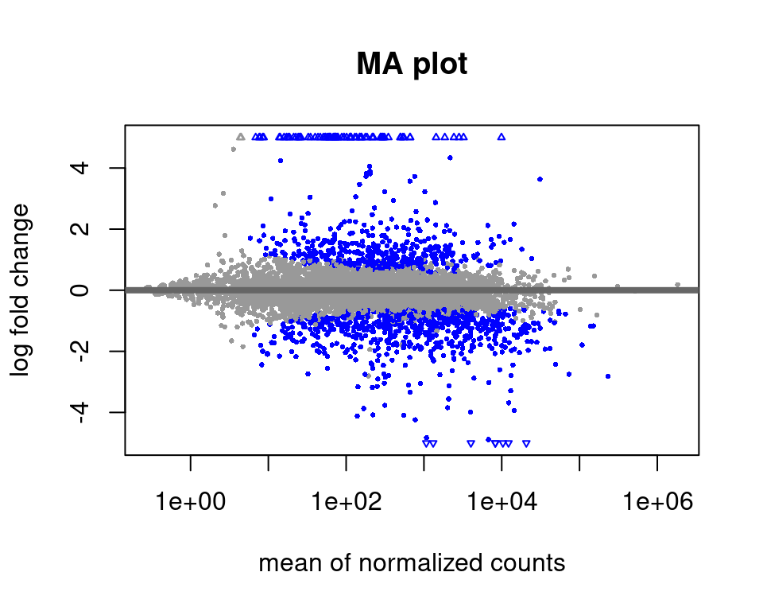

```r
DESeq2::plotMA(res, ylim=c(-5,5), main="MA plot")
```

### Volcano plot

The volcano plot arranges genes along two dimensions: the x-axis is the log fold change between the two groups, and the y-axis represents the adjusted P values between samples (on a negative log scale so smaller p-values appear higher up).

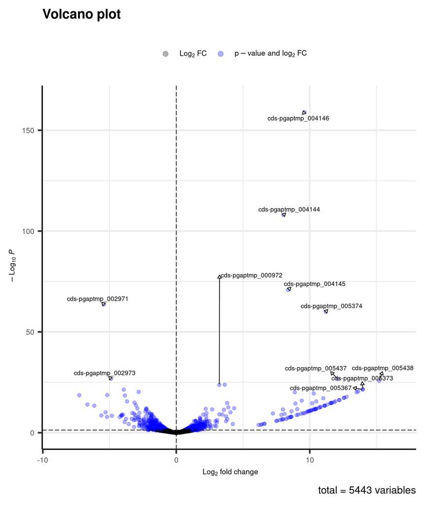

```r
EnhancedVolcano(res, lab = rownames(res), x = 'log2FoldChange', y = 'padj', pCutoff=0.05, FCcutoff=0, subtitleLabSize=0, axisLabSize=10, labSize=3, legendLabSize=10, legendIconSize=3, col=c('black', 'black', 'gold2', 'blue'), colAlpha = 0.3, drawConnectors = TRUE)
```